# DS6021 Final Project

Daniel Luettgen

8/5/2024

## Data Exploration

### Numeric Variables vs Temperature

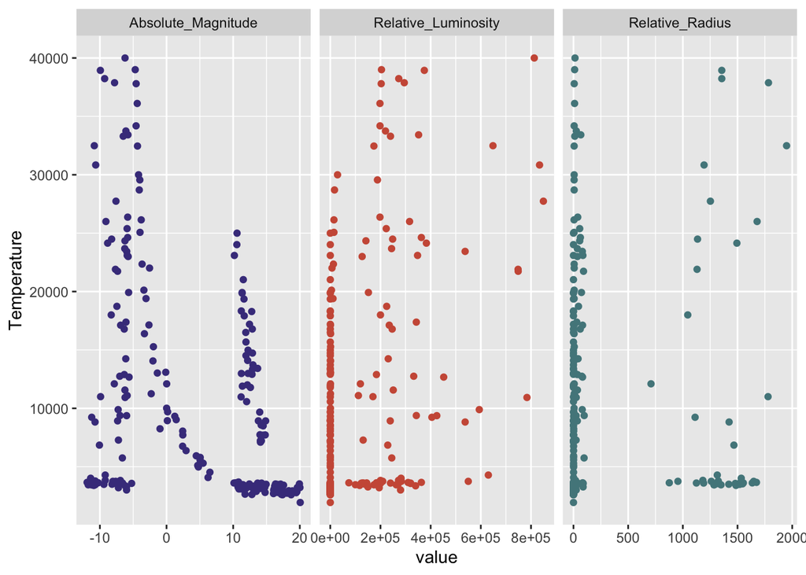

```r
#changing column names
names(stars) <- c("Temperature","Relative_Luminosity", "Relative_Radius", "Absolute_Magnitude","Color",
                   "Spectral_Class","Type")

#Facet wrap of individual variables
stars2 <- gather(stars, key="predictor", value="value", Relative_Luminosity, Relative_Radius, Absolute_Magnitude)
ggplot(stars2, aes(x=value, y=Temperature,color=predictor))+geom_point()+
  facet_wrap(~predictor,scales = "free_x")+scale_color_manual(values = c("Absolute_Magnitude" = "darkslateblue", "Relative_Luminosity" = "coral3", "Relative_Radius" = "cadetblue4"))+theme(legend.position = "none")
```

### Transform Luminosity, Temperature, and Radius

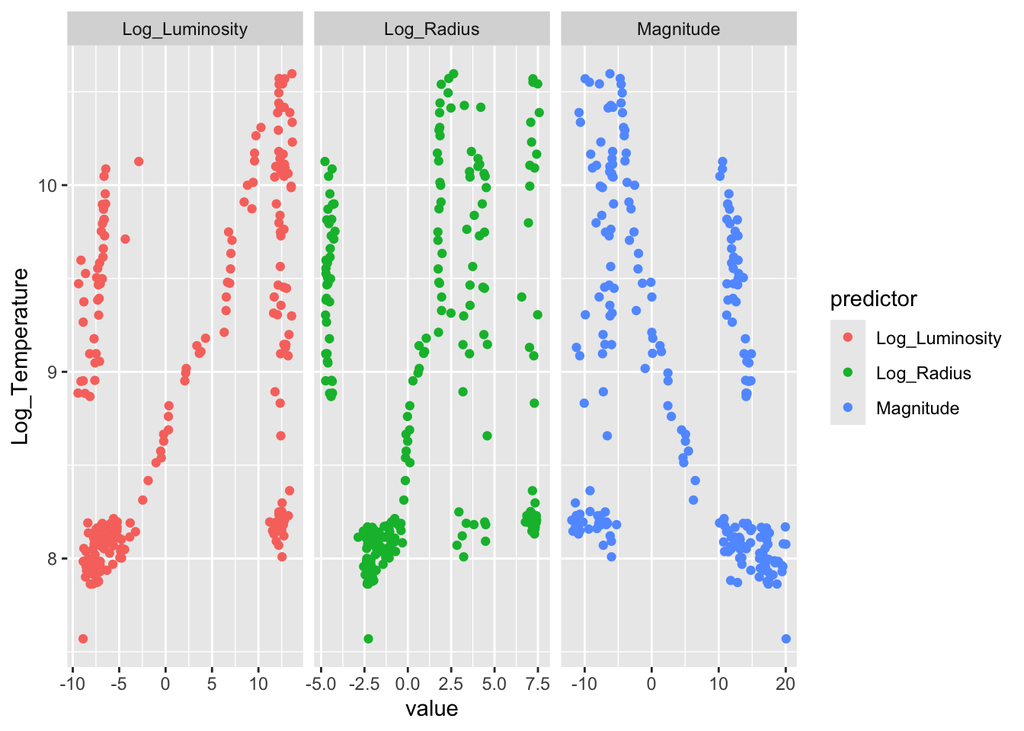

```r
#Log Transformations (except magnitude due to negatives)
stars_t <- mutate(stars, Log_Luminosity = log(Relative_Luminosity), Log_Temperature = log(Temperature), Log_Radius = log(Relative_Radius), Magnitude = Absolute_Magnitude)

stars_t2 <- gather(stars_t, key="predictor", value="value",
                  Log_Luminosity, Log_Radius, Magnitude)
#New facet wrap of transformations
ggplot(stars_t2, aes(x=value, y=Log_Temperature,color=predictor))+geom_point()+
  facet_wrap(~predictor,scales = "free_x")
```

### Checking for Multicollinearity

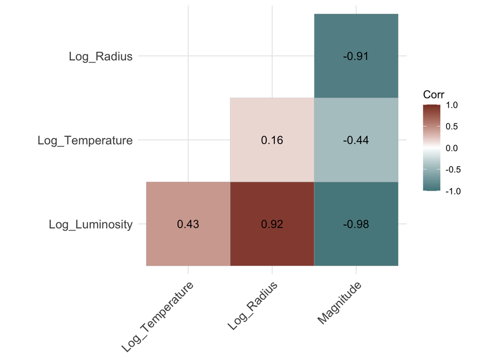

```r
stars_mc <- subset(stars_t, select = -c(Temperature, Relative_Luminosity, Relative_Radius, Absolute_Magnitude, Color,
                                         Spectral_Class,Type))
cor_mat <- round(cor(stars_mc),2)

ggcorrplot(cor_mat, lab=TRUE, type="lower", colors = c("cadetblue4","white","coral4"))
```

```r
stars <- read.csv("Data/Stars_cleanest_r.csv")
summary(stars %>% dplyr::select(Temperature, L, R, A_M))
```

```
##   Temperature          L                  R                  A_M
##  Min.   : 1939   Min.   :     0.0   Min.   :   0.0084   Min.   :-11.920
##  1st Qu.: 3344   1st Qu.:     0.0   1st Qu.:   0.1027   1st Qu.: -6.232
##  Median : 5776   Median :     0.1   Median :   0.7625   Median :  8.313
##  Mean   :10497   Mean   :107188.4   Mean   : 237.1578   Mean   :  4.382
##  3rd Qu.:15056   3rd Qu.:198050.0   3rd Qu.:  42.7500   3rd Qu.: 13.697
##  Max.   :40000   Max.   :849420.0   Max.   :1948.5000   Max.   : 20.060
```

The table above shows the distribution of numerical data in our dataset. Temperature, Luminosity, and Radius all have a very wide distribution, signaling that scaling may be necessary when constructing linear models.

## Multiple Linear Regression - LASSO Approach

```r
inimodel <- lm(Temperature~., data=stars[0:5])
summary(inimodel)
```

```
##
## Call:
## lm(formula = Temperature ~ ., data = stars[0:5])
##
## Residuals:
##      Min       1Q   Median       3Q      Max
## -15872.4  -2071.2    235.8    895.4  17672.0
##
## Coefficients:
##                     Estimate Std. Error t value Pr(>|t|)
## (Intercept)        2.050e+04  9.472e+02  21.648  < 2e-16 ***
## L                  4.311e-03  2.900e-03   1.486 0.138507
## R                  1.740e+00  9.600e-01   1.813 0.071179 .
## A_M                1.589e+01  5.419e+01   0.293 0.769665
## ColorBlue-White   -4.496e+03  1.177e+03  -3.819 0.000172 ***
## ColorRed_Orange   -1.813e+04  1.075e+03 -16.875  < 2e-16 ***
## ColorYellow_White -1.281e+04  1.338e+03  -9.573  < 2e-16 ***
## ---
## Signif. codes:  0 '***' 0.001 '**' 0.01 '*' 0.05 '.' 0.1 ' ' 1
##
## Residual standard error: 5264 on 233 degrees of freedom
## Multiple R-squared:  0.704,  Adjusted R-squared:  0.6964
## F-statistic: 92.36 on 6 and 233 DF,  p-value: < 2.2e-16
```

This naive initial model predicts Temperature from Luminosity, Radius, Absolute Magnitude, and Color. While the overall model is significant (p-value ~0), all of the numerical predictors are not significant. Referring back to the exploratory analysis section, this may be because of the large spread in data for Luminosity and Radius.

```r
stars2 <- mutate(stars, Temperature = log(Temperature), L = log(L), R = log(R))
inimodel2 <- lm(Temperature~., data=stars2[0:5])
summary(inimodel2)
```

```
##
## Call:
## lm(formula = Temperature ~ ., data = stars2[0:5])
##
## Residuals:
##      Min       1Q   Median       3Q      Max
## -1.26477 -0.10033 -0.00526  0.12873  0.68866
##
## Coefficients:
##                    Estimate Std. Error t value Pr(>|t|)
## (Intercept)        9.845283   0.079613 123.665  < 2e-16 ***
## L                  0.007951   0.011884   0.669  0.50410
## R                 -0.014473   0.018837  -0.768  0.44307
## A_M               -0.006686   0.010180  -0.657  0.51197
## ColorBlue-White   -0.206883   0.064553  -3.205  0.00154 **
## ColorRed_Orange   -1.677318   0.072307 -23.197  < 2e-16 ***
## ColorYellow_White -0.845808   0.081417 -10.389  < 2e-16 ***
## ---
## Signif. codes:  0 '***' 0.001 '**' 0.01 '*' 0.05 '.' 0.1 ' ' 1
##
## Residual standard error: 0.3057 on 233 degrees of freedom
## Multiple R-squared:  0.876,  Adjusted R-squared:  0.8728
## F-statistic: 274.3 on 6 and 233 DF,  p-value: < 2.2e-16
```

To perform feature selection, we turn to LASSO regularization.

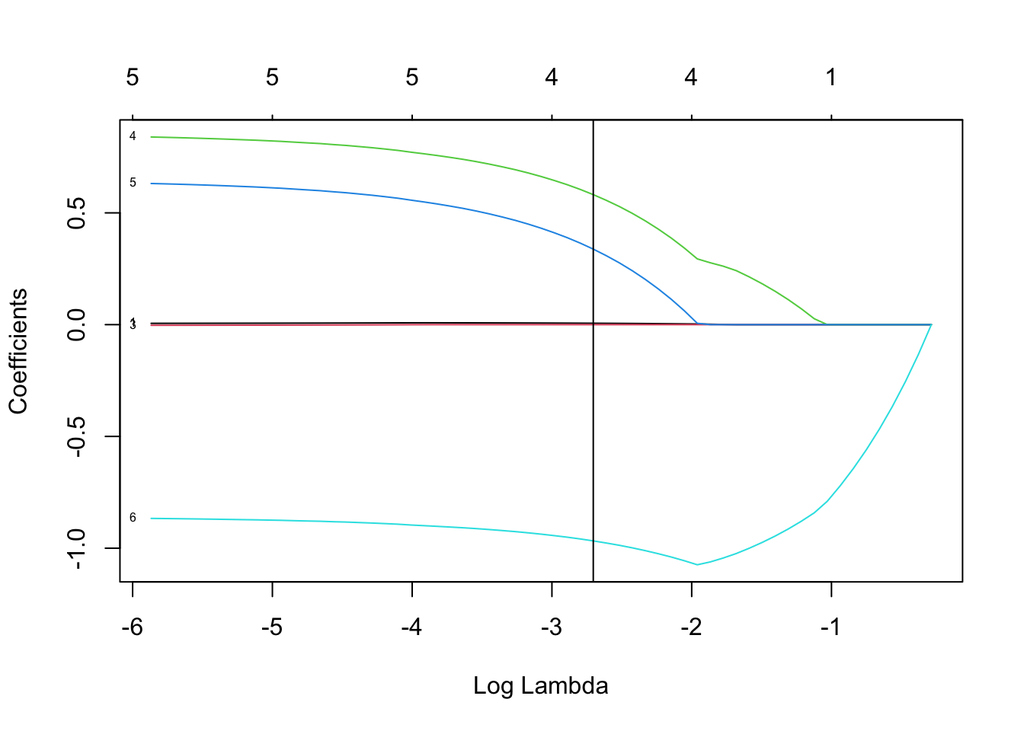

```
## integer(0)
```

```r
X<- model.matrix(Temperature~0+.,data=stars2[0:5])
y <- stars2[0:5]$Temperature
rmodel <- glmnet(x=X, y=y, alpha = 1)
kcvrmodel <- cv.glmnet(x=X, y=y, alpha = 1, nfolds=10)
# kcvrmodel$lambda.1se
plot(rmodel, label=T,xvar='lambda') + abline(v=log(kcvrmodel$lambda.1se))
```

```r
predict(rmodel, type="coefficient", s=kcvrmodel$lambda.1se, newx=X[1:10,])
```

```
## 8 x 1 sparse Matrix of class "dgCMatrix"
##                             s1
## (Intercept)        9.140975588
## L                  0.006197998
## R                  .
## A_M                .
## ColorBlue          0.581644882
## ColorBlue-White    0.337894902
## ColorRed_Orange   -0.967343623
## ColorYellow_White  .
```

Using a lambda value 1 standard deviation away from the lambda that minimizes RMSE, we see the LASSO regression has eliminated the Radius and Absolute Magnitude predictors. Seeing at least one of these removed was expected because these two predictors were highly correlated after transforming Radius. Although the LASSO regression eliminated the Yellow-White color, we opted to leave this categorical predictor in the model since the other 3 colors were found to be significant.

```r
goodmodel <- lm(Temperature~L+Color, data=stars2)
summary(goodmodel)
```

```
##
## Call:
## lm(formula = Temperature ~ L + Color, data = stars2)
##
## Residuals:
##      Min       1Q   Median       3Q      Max
## -1.27668 -0.10382 -0.00132  0.12631  0.70468
##
## Coefficients:
##                    Estimate Std. Error t value Pr(>|t|)
## (Intercept)        9.819806   0.045162 217.434  < 2e-16 ***
## L                  0.009202   0.002407   3.822 0.000169 ***
## ColorBlue-White   -0.203586   0.063666  -3.198 0.001576 **
## ColorRed_Orange   -1.712740   0.054356 -31.510  < 2e-16 ***
## ColorYellow_White -0.842838   0.075337 -11.188  < 2e-16 ***
## ---
## Signif. codes:  0 '***' 0.001 '**' 0.01 '*' 0.05 '.' 0.1 ' ' 1
##
## Residual standard error: 0.3049 on 235 degrees of freedom
## Multiple R-squared:  0.8756, Adjusted R-squared:  0.8735
## F-statistic: 413.5 on 4 and 235 DF,  p-value: < 2.2e-16
```

Following feature selection using LASSO regression, we created our final linear model using the chosen features. All of the predictors are shown to be significant in the model with p-values < .01.

The Adj. $R^2$ and RMSE are about the same as the model pre-feature selection, but based on the principal of parsimony, we conclude that this model is better.

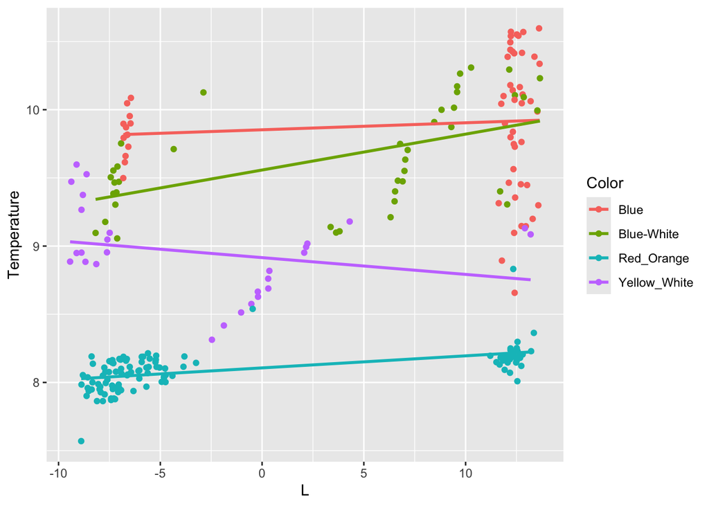

```r
ggplot(stars2, aes(x=L, y = Temperature, color=Color))+geom_jitter()+
  geom_smooth(method="lm", model.extract(stars2), se=FALSE)
```

#### Checking Assumptions

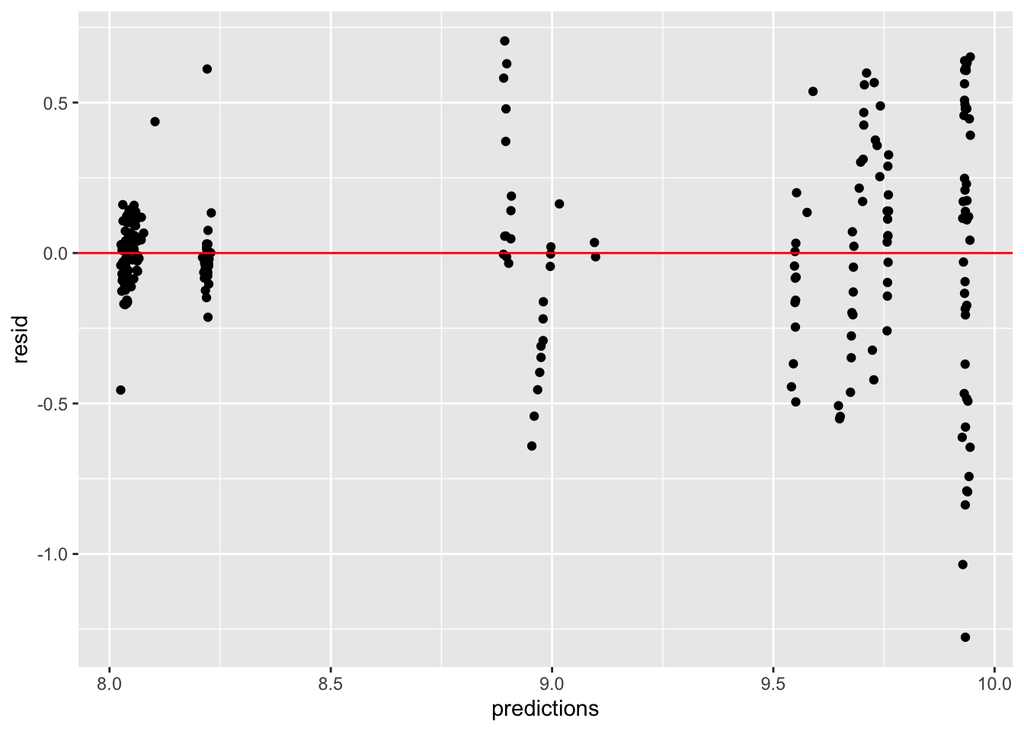

```r
star_pred <- mutate(stars2, predictions=fitted(goodmodel), resid=residuals(goodmodel))

ggplot(star_pred, aes(x=predictions, y=resid)) + geom_point() + geom_hline(yintercept = 0, color="red")
```

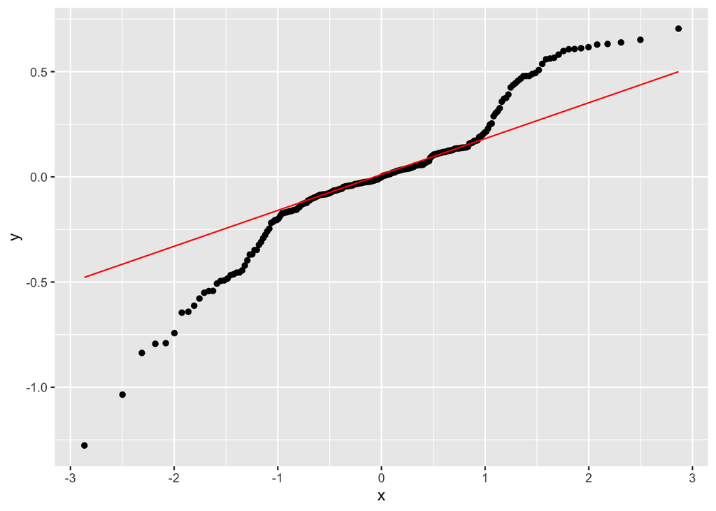

```r
ggplot(star_pred, aes(sample=resid)) + stat_qq() + stat_qq_line(color="red")
```

The QQ plot displays excellent results within the $[-1, 1]$ quantile range. However, after that we see the points diverge heavily from the $y=x$ line. This is an indication that the population may not be normally distributed in the extreme ranges of the data. This divergence calls the 4th assumption of a normal population into question.

#### Conculusion

Although we have a model that has relatively strong performance metrics, we struggle to validate all of the assumptions necessary for linear modeling. In the end, a linear model is likely not the best choice for our data-set.

```r
new_dat <- stars2[c(90,150,175,220),-1]
exp(predict(goodmodel, newdata = new_dat, interval = "prediction", level = .95))
```

```
##           fit      lwr       upr
## 90  17276.816 9386.641 31799.272
## 150 14065.516 7643.064 25884.742
## 175  3718.434 2027.297  6820.288
## 220  8082.346 4383.936 14900.838
```

```r
exp(predict(goodmodel, newdata = new_dat, interval = "confidence", level = .95))
```

```
##           fit       lwr       upr
## 90  17276.816 15524.178 19227.322
## 150 14065.516 12649.534 15640.003
## 175  3718.434  3415.741  4047.950
## 220  8082.346  7196.793  9076.865
```

```r
exp(stars2[c(90,150,175,220),1:2])
```

```
##     Temperature        L
## 90        19860 1.10e-03
## 150       12984 8.80e-04
## 175        3600 2.40e+05
## 220        8250 9.25e+00
```

## Logistic Regression

### One Vs. All

One Vs. All logistic regression is a method to use logistic regression to predict multiclass categorical variables. We will be attempting to predict star type from the natural log of Temperature, Luminosity, and Radius. For each star type, we train a logistic regression model that predicts either that star type, or not that star type. For example, the first model will predict whether a star is a Brown Dwarf or not a Brown Dwarf. At the end, the star type with the largest predicted probability will be labeled as the prediction from the model.

```r
# set a seed
set.seed(6021)

# Read in the data-set. Drop the first column
stars <- read.csv('Data/Stars_cleanest_r.csv')
stars <- stars %>% dplyr::select(Temperature, L, R, A_M, Color, Spectral_Class, Type)
stars <- stars %>% mutate(log_L = log(L), log_R=log(R), log_Temp=log(Temperature))
dummies <- dummyVars('~Type', data=stars)
stars_dummies <- data.frame(stars, predict(dummies, newdata=stars))
```

```r
# Split the data into train and test
train_sample <- sample(1:nrow(stars_dummies), .8*nrow(stars_dummies), replace=FALSE)
train_data <- stars_dummies[train_sample,]
test_data <- stars_dummies[-train_sample,]
```

We broke the data-set into a train and test data-set to evaluate model performance after training the model. A ridge regularization penalty was added to the model to introduce bias into the predictions. This is because some of the models without the penalty displayed perfect separation in the data, which yielded excellent accuracy, but poor p-values for the predictors.

```r
# Brown Dwarf Model
bd_X <- model.matrix(TypeBrown.Dwarf~0+log_L+log_R+log_Temp, data=train_data)
bd_y <- train_data$TypeBrown.Dwarf

bd_ridge_model <- glmnet(x=bd_X, y=bd_y, data=stars, alpha=0, family='binomial')

bd_cv_model <- cv.glmnet(x=bd_X, y=bd_y, data=stars, alpha=0, family='binomial', nfolds=10)

bd_train_probs <- predict(bd_ridge_model, newx=bd_X, s=bd_cv_model$lambda.min, type='response')
```

```r
# Red Dwarf Model
rd_X <- model.matrix(TypeRed.Dwarf~0+log_L+log_R+log_Temp, data=train_data)
rd_y <- train_data$TypeRed.Dwarf

rd_ridge_model <- glmnet(x=rd_X, y=rd_y, data=stars, alpha=0, family='binomial')

rd_cv_model <- cv.glmnet(x=rd_X, y=rd_y, data=stars, alpha=0, family='binomial', nfolds=10)

rd_train_probs <- predict(rd_ridge_model, newx=rd_X, s=rd_cv_model$lambda.min, type='response')
```

```r
# White Dwarf Model
wd_X <- model.matrix(TypeWhite.Dwarf~0+log_L+log_R+log_Temp, data=train_data)
wd_y <- train_data$TypeWhite.Dwarf

wd_ridge_model <- glmnet(x=wd_X, y=wd_y, data=stars, alpha=0, family='binomial')

wd_cv_model <- cv.glmnet(x=wd_X, y=wd_y, data=stars, alpha=0, family='binomial', nfolds=10)

wd_train_probs <- predict(wd_ridge_model, newx=wd_X, s=wd_cv_model$lambda.min, type='response')
```

```r
# Main Sequence Model
ms_X <- model.matrix(TypeMain.Sequence~0+log_L+log_R+log_Temp, data=train_data)
ms_y <- train_data$TypeMain.Sequence

ms_ridge_model <- glmnet(x=ms_X, y=ms_y, data=stars, alpha=0, family='binomial')

ms_cv_model <- cv.glmnet(x=ms_X, y=ms_y, data=stars, alpha=0, family='binomial', nfolds=10)

ms_train_probs <- predict(ms_ridge_model, newx=ms_X, s=ms_cv_model$lambda.min, type='response')
```

```r
# Hyper Giants Model
hg_X <- model.matrix(TypeHyper.Giants~0+log_L+log_R+log_Temp, data=train_data)
hg_y <- train_data$TypeHyper.Giants

hg_ridge_model <- glmnet(x=hg_X, y=hg_y, data=stars, alpha=0, family='binomial')

hg_cv_model <- cv.glmnet(x=hg_X, y=hg_y, data=stars, alpha=0, family='binomial', nfolds=10)

hg_train_probs <- predict(hg_ridge_model, newx=hg_X, s=hg_cv_model$lambda.min, type='response')
```

```r
# Super Giants Model
sg_X <- model.matrix(TypeSuper.Giants~0+log_L+log_R+log_Temp, data=train_data)
sg_y <- train_data$TypeSuper.Giants

sg_ridge_model <- glmnet(x=sg_X, y=sg_y, data=stars, alpha=0, family='binomial')

sg_cv_model <- cv.glmnet(x=sg_X, y=sg_y, data=stars, alpha=0, family='binomial', nfolds=10)

sg_train_probs <- predict(sg_ridge_model, newx=sg_X, s=sg_cv_model$lambda.min, type='response')
```

```r
train_probs <- data.frame(bd_train_probs, rd_train_probs, wd_train_probs, ms_train_probs, hg_train_probs, sg_train_probs)
colnames(train_probs) <- c('Brown Dwarf', 'Red Dwarf', 'White Dwarf', 'Main Sequence', 'Hyper Giants', 'Super Giants')

train_rowmax <- apply(train_probs, 1, max)
train_log_odds <- train_rowmax / log(1-train_rowmax)
train_rowmax_index <- apply(train_probs, 1, which.max)

train_preds <- colnames(train_probs)[train_rowmax_index]

paste('Training Accuracy:', sum((as.integer(train_preds == train_data$Type)) / nrow(train_data)))
```

```
## [1] "Training Accuracy: 0.90625"
```

```r
M_train <- as.matrix(train_data[,11:16])
colnames(M_train) <- c("Brown Dwarf", "Hyper Giants", "Main Sequence", "Red Dwarf", "Super Giants", "White Dwarf")
pROC::multiclass.roc(train_preds, M_train)
```

```
##
## Call:
## multiclass.roc.default(response = train_preds, predictor = M_train)
##
## Data: multivariate predictor M_train with 6 levels of train_preds: Brown Dwarf, Hyper Giants, Main Sequence, Red Dwarf, Super Giants, White Dwarf.
## Multi-class area under the curve: 0.947
```

```r
confusionMatrix(as.factor(train_preds), as.factor(train_data$Type))
```

```
## Confusion Matrix and Statistics
##
##                Reference
## Prediction      Brown Dwarf Hyper Giants Main Sequence Red Dwarf Super Giants
##   Brown Dwarf            24            0             5         0            0
##   Hyper Giants            0           33             0         0            3
##   Main Sequence           0            0            27         0            2
##   Red Dwarf               8            0             0        31            0
##   Super Giants            0            0             0         0           26
##   White Dwarf             0            0             0         0            0
##                Reference
## Prediction      White Dwarf
##   Brown Dwarf             0
##   Hyper Giants            0
##   Main Sequence           0
##   Red Dwarf               0
##   Super Giants            0
##   White Dwarf            33
##
## Overall Statistics
##
##                Accuracy : 0.9062
##                  95% CI : (0.8559, 0.9435)
##     No Information Rate : 0.1719
##     P-Value [Acc > NIR] : < 2.2e-16
##
##                   Kappa : 0.8875
##
##  Mcnemar's Test P-Value : NA
##
## Statistics by Class:
##
##                      Class: Brown Dwarf Class: Hyper Giants
## Sensitivity                      0.7500              1.0000
## Specificity                      0.9688              0.9811
## Pos Pred Value                   0.8276              0.9167
## Neg Pred Value                   0.9509              1.0000
## Prevalence                       0.1667              0.1719
## Detection Rate                   0.1250              0.1719
## Detection Prevalence             0.1510              0.1875
## Balanced Accuracy                0.8594              0.9906
##                      Class: Main Sequence Class: Red Dwarf Class: Super Giants
## Sensitivity                        0.8438           1.0000              0.8387
## Specificity                        0.9875           0.9503              1.0000
## Pos Pred Value                     0.9310           0.7949              1.0000
## Neg Pred Value                     0.9693           1.0000              0.9699
## Prevalence                         0.1667           0.1615              0.1615
## Detection Rate                     0.1406           0.1615              0.1354
## Detection Prevalence               0.1510           0.2031              0.1354
## Balanced Accuracy                  0.9156           0.9752              0.9194
##                      Class: White Dwarf
## Sensitivity                      1.0000
## Specificity                      1.0000
## Pos Pred Value                   1.0000
## Neg Pred Value                   1.0000
## Prevalence                       0.1719
## Detection Rate                   0.1719
## Detection Prevalence             0.1719
## Balanced Accuracy                1.0000
```

After training each logistic regression model, we evaluate the performance of the combination of models. We predict the star type based on which star type’s logistic regression model yielded the largest probability against all others. With the training data, we have ~90% accuracy and ~.94 AUC, indicating an effective model against the training data.

We then turn to testing the trained model against the testing data-set.

```r
# Test the model
bd_test_X <- model.matrix(TypeBrown.Dwarf~0+log_L+log_R+log_Temp, data=test_data)
bd_test_y <- test_data$TypeBrown.Dwarf
bd_test_probs <- predict(bd_ridge_model, newx=bd_test_X, s=bd_cv_model$lambda.min, type='response')

rd_test_X <- model.matrix(TypeRed.Dwarf~0+log_L+log_R+log_Temp, data=test_data)
rd_test_y <- test_data$TypeRed.Dwarf
rd_test_probs <- predict(rd_ridge_model, newx=rd_test_X, s=rd_cv_model$lambda.min, type='response')

wd_test_X <- model.matrix(TypeWhite.Dwarf~0+log_L+log_R+log_Temp, data=test_data)
wd_test_y <- test_data$TypeWhite.Dwarf
wd_test_probs <- predict(wd_ridge_model, newx=wd_test_X, s=wd_cv_model$lambda.min, type='response')

ms_test_X <- model.matrix(TypeMain.Sequence~0+log_L+log_R+log_Temp, data=test_data)
ms_test_y <- test_data$TypeMain.Sequence
ms_test_probs <- predict(ms_ridge_model, newx=ms_test_X, s=ms_cv_model$lambda.min, type='response')

hg_test_X <- model.matrix(TypeHyper.Giants~0+log_L+log_R+log_Temp, data=test_data)
hg_test_y <- test_data$TypeHyper.Giants
hg_test_probs <- predict(hg_ridge_model, newx=hg_test_X, s=hg_cv_model$lambda.min, type='response')

sg_test_X <- model.matrix(TypeSuper.Giants~0+log_L+log_R+log_Temp, data=test_data)
sg_test_y <- test_data$TypeSuper.Giants
sg_test_probs <- predict(sg_ridge_model, newx=sg_test_X, s=sg_cv_model$lambda.min, type='response')

test_probs <- data.frame(bd_test_probs, rd_test_probs, wd_test_probs, ms_test_probs, hg_test_probs, sg_test_probs)
colnames(test_probs) <- c('Brown Dwarf', 'Red Dwarf', 'White Dwarf', 'Main Sequence', 'Hyper Giants', 'Super Giants')

test_rowmax <- apply(test_probs, 1, max)
test_log_odds <- test_rowmax / log(1-test_rowmax)
test_rowmax_index <- apply(test_probs, 1, which.max)

test_preds <- colnames(test_probs)[test_rowmax_index]

paste('testing Accuracy:', sum((as.integer(test_preds == test_data$Type)) / nrow(test_data)))
```

```
## [1] "testing Accuracy: 0.770833333333333"
```

```r
M_test <- as.matrix(test_data[,11:16])
colnames(M_test) <- c("Brown Dwarf", "Hyper Giants", "Main Sequence", "Red Dwarf", "Super Giants", "White Dwarf")
pROC::multiclass.roc(test_preds, M_test)
```

```
##
## Call:
## multiclass.roc.default(response = test_preds, predictor = M_test)
##
## Data: multivariate predictor M_test with 6 levels of test_preds: Brown Dwarf, Hyper Giants, Main Sequence, Red Dwarf, Super Giants, White Dwarf.
## Multi-class area under the curve: 0.8732
```

```r
confusionMatrix(as.factor(test_preds), as.factor(test_data$Type))
```

```
## Confusion Matrix and Statistics
##
##                Reference
## Prediction      Brown Dwarf Hyper Giants Main Sequence Red Dwarf Super Giants
##   Brown Dwarf             3            0             3         0            0
##   Hyper Giants            0            7             0         0            1
##   Main Sequence           0            0             5         0            2
##   Red Dwarf               5            0             0         9            0
##   Super Giants            0            0             0         0            6
##   White Dwarf             0            0             0         0            0
##                Reference
## Prediction      White Dwarf
##   Brown Dwarf             0
##   Hyper Giants            0
##   Main Sequence           0
##   Red Dwarf               0
##   Super Giants            0
##   White Dwarf             7
##
## Overall Statistics
##
##                Accuracy : 0.7708
##                  95% CI : (0.6269, 0.8797)
##     No Information Rate : 0.1875
##     P-Value [Acc > NIR] : < 2.2e-16
##
##                   Kappa : 0.7243
##
##  Mcnemar's Test P-Value : NA
##
## Statistics by Class:
##
##                      Class: Brown Dwarf Class: Hyper Giants
## Sensitivity                      0.3750              1.0000
## Specificity                      0.9250              0.9756
## Pos Pred Value                   0.5000              0.8750
## Neg Pred Value                   0.8810              1.0000
## Prevalence                       0.1667              0.1458
## Detection Rate                   0.0625              0.1458
## Detection Prevalence             0.1250              0.1667
## Balanced Accuracy                0.6500              0.9878
##                      Class: Main Sequence Class: Red Dwarf Class: Super Giants
## Sensitivity                        0.6250           1.0000              0.6667
## Specificity                        0.9500           0.8718              1.0000
## Pos Pred Value                     0.7143           0.6429              1.0000
## Neg Pred Value                     0.9268           1.0000              0.9286
## Prevalence                         0.1667           0.1875              0.1875
## Detection Rate                     0.1042           0.1875              0.1250
## Detection Prevalence               0.1458           0.2917              0.1250
## Balanced Accuracy                  0.7875           0.9359              0.8333
##                      Class: White Dwarf
## Sensitivity                      1.0000
## Specificity                      1.0000
## Pos Pred Value                   1.0000
## Neg Pred Value                   1.0000
## Prevalence                       0.1458
## Detection Rate                   0.1458
## Detection Prevalence             0.1458
## Balanced Accuracy                1.0000
```

Next, we turn to evaluating the linearity assumption for logistic regression.

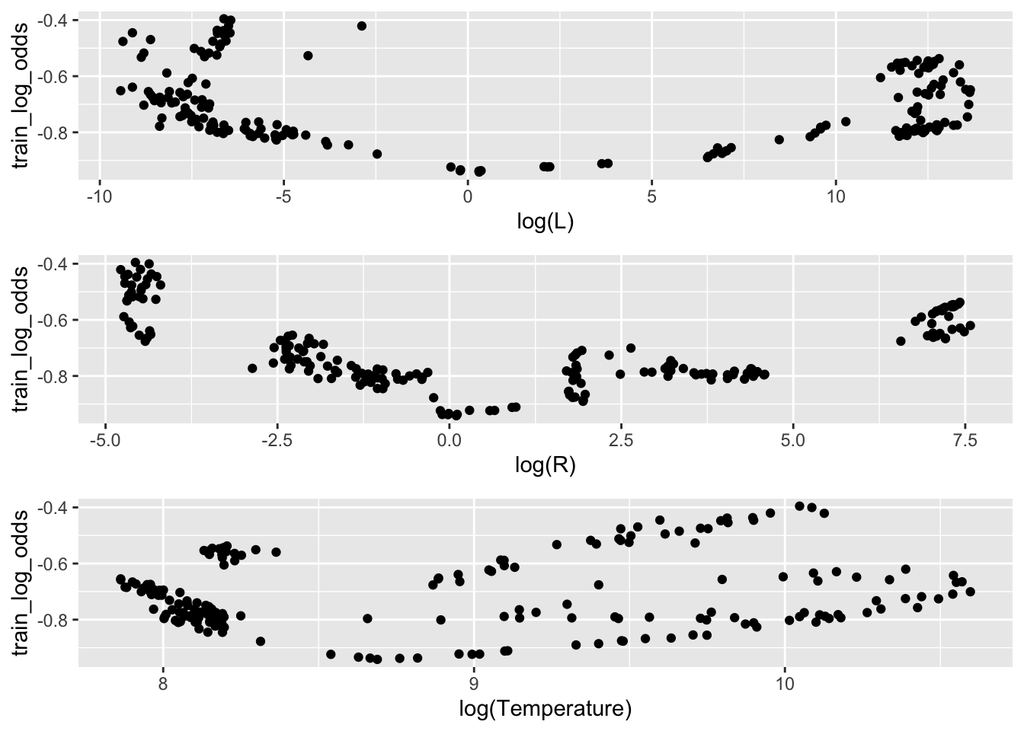

```r
log_L_plot <- ggplot(mapping=aes(x=train_data$log_L, y=train_log_odds)) + geom_point() + xlab('log(L)')
log_R_plot <- ggplot(mapping=aes(x=train_data$log_R, y=train_log_odds)) + geom_point() + xlab('log(R)')
log_Temp_plot <- ggplot(mapping=aes(x=train_data$log_Temp, y=train_log_odds)) + geom_point() + xlab('log(Temperature)')
grid.arrange(log_L_plot, log_R_plot, log_Temp_plot)
```

The plots above show each predictor against the predicted log odds of the train data-set. None of the plots show a distinct linear relationship as they all show some parabolic curving. This brings the linearity assumption into question for this One Vs. All logistic model. Although the model performs well, it may not perform well on future data. In order to dive deeper into validating the linearity assumption, or improve model performance, a larger data-set would be useful.

### Multinomial Regression

In addition to one-vs-all logistic regression, we also found a second method for predicting a categorical variable with more than 2 features known as multinomial logistic regression. The difference between multinomial logistic regression and one-vs-all logistic regression is that multinomial minimizes the negative log-odds that of each class relative to a reference class rather than all of the other classes.

```r
stars <- read.csv("Data/Stars_clean_r.csv")

# Convert 'Type' column to factor
stars$Type <- as.factor(stars$Type)

# Remove rows with missing values
stars <- na.omit(stars)

# Remove categorical columns except 'Type'
stars_numeric <- stars[, sapply(stars, is.numeric)]
stars_numeric$Type <- stars$Type

# Create a training and testing set
set.seed(1)
trainIndex <- createDataPartition(stars_numeric$Type, p = 0.8, list = FALSE)
trainData <- stars_numeric[trainIndex, ]
testData <- stars_numeric[-trainIndex, ]

# Separate predictors and response
x_train <- trainData[, -which(names(trainData) == "Type")]
y_train <- trainData$Type
x_test <- testData[, -which(names(testData) == "Type")]
y_test <- testData$Type

# Train the multinomial logistic regression model
mlr_model <- multinom(Type ~ ., data = trainData, model = T)
summary(mlr_model)
```

```
## Call:
## multinom(formula = Type ~ ., data = trainData, model = T)
##
## Coefficients:
##               (Intercept) Temperature             L           R           A_M
## Hyper Giants  -107.513049 0.008117816 -1.680863e-04  0.15474336   0.002842198
## Main Sequence   -6.430113 0.011621929 -6.375170e-04 -0.16131272  -4.885229853
## Red Dwarf     -443.606786 0.006124183  3.094101e-05  0.43452771  27.447374908
## Super Giants   -43.238901 0.006922427 -1.023234e-04 -0.21334062 -20.593175340
## White Dwarf   -283.701033 0.020487265 -8.405431e-04  0.04565801  12.323133940
##
## Std. Errors:
##                (Intercept) Temperature            L            R          A_M
## Hyper Giants  6.469267e-07  0.01856803 3.962483e-01 5.260072e-04 4.982941e-06
## Main Sequence 3.272765e-05  0.04314820 1.336212e-02 1.688953e-03 4.548580e-04
## Red Dwarf     3.313631e-05  0.11333024 4.788364e-01 1.436480e-03 4.996635e-04
## Super Giants  1.771764e-05  0.16362539 1.335887e-02 1.724577e-03 1.648274e-04
## White Dwarf   6.045540e-06  0.06637997 4.473620e-09 5.259665e-08 6.764971e-05
##
## Residual Deviance: 0.0001092784
## AIC: 50.00011
```

The above code cleans the data, creates an 80/20 train/test split and trains the model with the training data. The summary of the model is generated using the summary() function. The summary includes the final coefficients for each model. The coefficients show the log-odds of each class compared to the reference class. To make predictions on test data, the class with the greatest odds for the test data is returned as the prediction. If all of the odds are less than one, the reference class is predicted.

Next, we test our model on our testing data.

```r
# Predict on the test set
mlr_pred <- predict(mlr_model, newdata = testData)

# Evaluate the model
conf_matrix <- confusionMatrix(mlr_pred, y_test)
accuracy <- conf_matrix$overall['Accuracy']
cat("Accuracy of Multinomial Logistic Regression: ", accuracy, "\n")
```

```
## Accuracy of Multinomial Logistic Regression:  0.9791667
```

```r
print(conf_matrix)
```

```
## Confusion Matrix and Statistics
##
##                Reference
## Prediction      Brown Dwarf Hyper Giants Main Sequence Red Dwarf Super Giants
##   Brown Dwarf             8            0             0         0            0
##   Hyper Giants            0            7             0         0            0
##   Main Sequence           0            0             8         0            0
##   Red Dwarf               0            1             0         8            0
##   Super Giants            0            0             0         0            8
##   White Dwarf             0            0             0         0            0
##                Reference
## Prediction      White Dwarf
##   Brown Dwarf             0
##   Hyper Giants            0
##   Main Sequence           0
##   Red Dwarf               0
##   Super Giants            0
##   White Dwarf             8
##
## Overall Statistics
##
##                Accuracy : 0.9792
##                  95% CI : (0.8893, 0.9995)
##     No Information Rate : 0.1667
##     P-Value [Acc > NIR] : < 2.2e-16
##
##                   Kappa : 0.975
##
##  Mcnemar's Test P-Value : NA
##
## Statistics by Class:
##
##                      Class: Brown Dwarf Class: Hyper Giants
## Sensitivity                      1.0000              0.8750
## Specificity                      1.0000              1.0000
## Pos Pred Value                   1.0000              1.0000
## Neg Pred Value                   1.0000              0.9756
## Prevalence                       0.1667              0.1667
## Detection Rate                   0.1667              0.1458
## Detection Prevalence             0.1667              0.1458
## Balanced Accuracy                1.0000              0.9375
##                      Class: Main Sequence Class: Red Dwarf Class: Super Giants
## Sensitivity                        1.0000           1.0000              1.0000
## Specificity                        1.0000           0.9750              1.0000
## Pos Pred Value                     1.0000           0.8889              1.0000
## Neg Pred Value                     1.0000           1.0000              1.0000
## Prevalence                         0.1667           0.1667              0.1667
## Detection Rate                     0.1667           0.1667              0.1667
## Detection Prevalence               0.1667           0.1875              0.1667
## Balanced Accuracy                  1.0000           0.9875              1.0000
##                      Class: White Dwarf
## Sensitivity                      1.0000
## Specificity                      1.0000
## Pos Pred Value                   1.0000
## Neg Pred Value                   1.0000
## Prevalence                       0.1667
## Detection Rate                   0.1667
## Detection Prevalence             0.1667
## Balanced Accuracy                1.0000
```

The model is able to accurately identify the correct class of the test data 98% of the time. While these predictions are very accurate, it should be noted that the linearity assumption for multinomial logistic regression is not met.